# Entrega Final - Proyecto de Predicción de Tributos

Pablo Proaño

2025-12-05

## Analítica de Datos Industriales para la Toma de Decisiones con Apoyo de AI (Curso ADI&TD-IA)

## **PROYECTO FINAL**

### Datos del Estudiante:

**Nombre:** Pablo Andrés Proaño Chamorro

**mail:** pablo.proano@epn.edu.ec

**Carrera:** Doctorado en Ingeniería Industrial

# Introducción

## Descripción del Proyecto

El presente proyecto tiene como objetivo analizar un conjunto de datos correspondiente a operaciones de importación registradas por el Servicio Nacional de Aduana del Ecuador (SENAE), específicamente del conjunto SENAE_Importaciones Régimen General, el cual contiene el detalle de las importaciones por fecha de ingreso de la Declaración Aduanera de Importación (DAI) con estado de salida autorizada. La base de datos, disponible en formato CSV y actualizada a diciembre de 2025, es utilizada para procesos de carga, depuración, análisis estadístico, visualización y modelado predictivo de variables relacionadas con valores comerciales, cantidades e impuestos.

## Descripción de la Base de Datos

La base de datos utilizada corresponde al conjunto SENAE_Importaciones Régimen General, publicado por el SENAE, y contiene información detallada de las operaciones de importación registradas mediante la DAI. El conjunto se presenta en formato CSV y está compuesto por variables categóricas y numéricas asociadas al régimen, subpartida, país de origen, peso, valores comerciales, cantidades e impuestos, lo que permite un análisis integral de los aspectos comerciales y tributarios de las operaciones.

## Objetivo del Proyecto

Para el desarrollo del proyecto se consideran como **variables de entrada** aquellas asociadas a la información conocida al arribo de la mercancía a Aduana, tales como REGIMEN, SUBPARTIDA, PAIS_ORIGEN, CONVENIO_INTERNACIONAL, PESO_NETO, CANTIDAD_FISICA, CANTIDAD_COMERCIAL, TIPO_UNIDAD_FISICA, TIPO_UNIDAD_COMERCIAL, FOB, FLETE, SEGURO y CIF. Como **variables de salida** se definen los principales tributos: IVA, ADVALOREM y FODINFA.

Si bien estos valores se determinan mediante normativa, tablas arancelarias y fórmulas específicas, el objetivo del proyecto es desarrollar modelos predictivos basados en datos que permitan estimar dichos tributos utilizando únicamente la información histórica disponible, sin requerir el conocimiento explícito de las ecuaciones de cálculo.

# Base de Datos

## Carga y tratamiento de Datos

La base de datos utilizada fue descargada desde la página web previamente descrita en formato CSV. Posteriormente, fue cargada dentro del presente proyecto y almacenada en el repositorio de GitHub con el fin de garantizar la reproducibilidad del análisis. A continuación, se procede a la carga de los datos en el entorno de trabajo:

```r
library(readr)
aduana  <- read_delim("https://raw.githubusercontent.com/PjosP/Entrega_Final_Pablo_Proano/refs/heads/main/base_aduana_10.csv",
    delim = "|", escape_double = FALSE, trim_ws = TRUE)
head(aduana)
```

```
## # A tibble: 6 × 30
##   TIPO_IMPORTACION ESTADO_DECLARACION   FEC_INGRESO DISTRITO  REGIMEN SUBPARTIDA
##   <chr>            <chr>                <date>      <chr>     <chr>        <dbl>
## 1 IMP.GRAL.        10-SALIDA AUTORIZADA 2025-04-01  028-GUAY… 10-IMP… 9032100000
## 2 IMP.GRAL.        10-SALIDA AUTORIZADA 2025-09-08  028-GUAY… 10-IMP… 8544300000
## 3 IMP.GRAL.        10-SALIDA AUTORIZADA 2025-04-25  028-GUAY… 10-IMP… 8215200000
## 4 IMP.GRAL.        10-SALIDA AUTORIZADA 2025-06-03  055-QUITO 10-IMP… 9617000000
## 5 IMP.GRAL.        10-SALIDA AUTORIZADA 2025-06-22  055-QUITO 10-IMP… 6202900000
## 6 IMP.GRAL.        10-SALIDA AUTORIZADA 2025-02-21  028-GUAY… 70-DEP… 9505900000
## # ℹ 24 more variables: CODIGO_COMPLEMENTARIO <dbl>, CODIGO_SUPLEMENTARIO <dbl>,
## #   DESCRIPCION_ARANCELARIA <chr>, PAIS_ORIGEN <chr>, CODIGO_LIBERACION <chr>,
## #   TRATAMIENTO_PREFERENCIAL <chr>, CONVENIO_INTERNACIONAL <chr>,
## #   TIPO_UNIDAD_FISICA <chr>, TIPO_UNIDAD_COMERCIAL <chr>, PESO_NETO <dbl>,
## #   FOB <dbl>, FLETE <dbl>, SEGURO <dbl>, CIF <dbl>, CANTIDAD_FISICA <dbl>,
## #   CANTIDAD_COMERCIAL <dbl>, SALVAGUARDIA <dbl>,
## #   SALVAGUARDIA_ESPECIFICA <dbl>, FODINFA <dbl>, ICE_ADVALOREM <dbl>, …
```

## Descripción de la Base de Datos

A continuación, se procede a revisar las dimensiones de la base de datos, con el objetivo de identificar el número total de observaciones (filas) y variables (columnas) disponibles para el análisis. Esta verificación inicial permite evaluar el tamaño del conjunto de datos y confirmar que la carga de la información se haya realizado correctamente.

```r
dim(aduana)
```

```
## [1] 133493     30
```

A continuación, se procede a identificar el tipo de dato de cada una de las variables de la base de datos, con el fin de verificar su correcta interpretación (numérica, categórica o de fecha) y asegurar su adecuado tratamiento en las etapas posteriores de análisis y modelado.

```r
sapply(aduana, class)
```

```
##         TIPO_IMPORTACION       ESTADO_DECLARACION              FEC_INGRESO
##              "character"              "character"                   "Date"
##                 DISTRITO                  REGIMEN               SUBPARTIDA
##              "character"              "character"                "numeric"
##    CODIGO_COMPLEMENTARIO     CODIGO_SUPLEMENTARIO  DESCRIPCION_ARANCELARIA
##                "numeric"                "numeric"              "character"
##              PAIS_ORIGEN        CODIGO_LIBERACION TRATAMIENTO_PREFERENCIAL
##              "character"              "character"              "character"
##   CONVENIO_INTERNACIONAL       TIPO_UNIDAD_FISICA    TIPO_UNIDAD_COMERCIAL
##              "character"              "character"              "character"
##                PESO_NETO                      FOB                    FLETE
##                "numeric"                "numeric"                "numeric"
##                   SEGURO                      CIF          CANTIDAD_FISICA
##                "numeric"                "numeric"                "numeric"
##       CANTIDAD_COMERCIAL             SALVAGUARDIA  SALVAGUARDIA_ESPECIFICA
##                "numeric"                "numeric"                "numeric"
##                  FODINFA            ICE_ADVALOREM           ICE_ESPECIFICO
##                "numeric"                "numeric"                "numeric"
##                      IVA                ADVALOREM     ADVALOREM_ESPECIFICO
##                "numeric"                "numeric"                "numeric"
```

## Tratamiento Inicial de los Datos

En esta etapa se verifica la calidad inicial de la información, evaluando la existencia de **valores faltantes (NA)** y **filas duplicadas**, con el objetivo de garantizar la consistencia del conjunto de datos antes de aplicar los procesos de análisis y modelado.

```r
anyNA(aduana)
```

```
## [1] FALSE
```

```r
anyDuplicated(aduana)
```

```
## [1] 0
```

Se verificó que la base de datos no presenta valores faltantes ni registros duplicados, por lo que no fue necesario aplicar procesos de imputación o depuplicación. Sin embargo, se identificaron algunas columnas que no resultan relevantes para los objetivos del presente estudio. En consecuencia, se procede a crear una nueva base de datos que contenga únicamente las variables consideradas pertinentes para el análisis, la cual se denominará **base_seleccionada**:

```r
# Definimos las variables de entrada
vars_entrada <- c(
  "REGIMEN", "SUBPARTIDA", "PAIS_ORIGEN", "CONVENIO_INTERNACIONAL",
  "PESO_NETO", "CANTIDAD_FISICA", "CANTIDAD_COMERCIAL",
  "TIPO_UNIDAD_FISICA", "TIPO_UNIDAD_COMERCIAL",
  "FOB", "FLETE", "SEGURO", "CIF"
)

# Definimos las variables de salida
vars_salida <- c(
  "ADVALOREM",   "FODINFA", "IVA"
)

# Unimos las variables seleccionadas
vars_seleccionadas <- c(vars_entrada, vars_salida)

# Creamos la nueva base de datos
base_seleccionada <- aduana[, vars_seleccionadas]

# Verificación básica
dim(base_seleccionada)
```

```
## [1] 133493     16
```

# Análisis Multivariante

## Análisis Relacional de Datos

Con el fin de evaluar la viabilidad del proyecto, se procede a calcular la **matriz de covarianzas**, la cual permite analizar el grado de relación existente entre las variables y determinar si es posible establecer modelos predictivos en los que unas variables puedan ser estimadas en función de otras.

Previo a este análisis, se realiza la ransformación de las variables categóricas a formato numérico, con el objetivo de permitir el cálculo de medidas estadísticas multivariantes. Los resultados de esta transformación se almacenan en una nueva base de datos denominada **`base_numerica`**.

```r
# Se identificaron automáticamente las columnas que son de tipo carácter (texto)
vars_char <- names(base_seleccionada)[sapply(base_seleccionada, is.character)]

# Se creó una copia de la base original para trabajar con la versión numérica
base_numerica <- base_seleccionada

# Se transformaron las variables categóricas a valores numéricos mediante codificación de factores
base_numerica[vars_char] <- lapply(base_numerica[vars_char], function(x) {
  as.numeric(as.factor(x))
})

# Se verificó el tipo de dato de todas las columnas luego de la transformación
sapply(base_numerica, class)
```

```
##                REGIMEN             SUBPARTIDA            PAIS_ORIGEN
##              "numeric"              "numeric"              "numeric"
## CONVENIO_INTERNACIONAL              PESO_NETO        CANTIDAD_FISICA
##              "numeric"              "numeric"              "numeric"
##     CANTIDAD_COMERCIAL     TIPO_UNIDAD_FISICA  TIPO_UNIDAD_COMERCIAL
##              "numeric"              "numeric"              "numeric"
##                    FOB                  FLETE                 SEGURO
##              "numeric"              "numeric"              "numeric"
##                    CIF              ADVALOREM                FODINFA
##              "numeric"              "numeric"              "numeric"
##                    IVA
##              "numeric"
```

**Nota:** Inicialmente, yo solía hacer esta transformación de variables categóricas a numéricas de forma manual en python usando una función propia. Posteriormente investigando para la realización de este proyecto, se identificaron dos métodos automáticos para este proceso: la **codificación mediante factores** y la **codificación One-Hot Encoding**.

El primer método resulta adecuado para modelos basados en árboles y algoritmos que no dependen de relaciones lineales entre variables. Dado que en este proyecto se emplea **Random Forest**, se optó por la codificación mediante factores, evitando además un incremento innecesario en la dimensionalidad de la base de datos.

Posteriormente, se procede a la normalización de la base de datos, con el objetivo de homogeneizar la escala de las variables numéricas. El resultado de este proceso se almacena en una nueva base de datos denominada **`base_normalizada`**.

```r
# Función de normalización Min-Max
normalizar_minmax <- function(x) {
  (x - min(x)) / (max(x) - min(x))
}

# Aplicación de la normalización a todas las columnas
base_normalizada <- as.data.frame(
  lapply(base_numerica, normalizar_minmax)
)

# Verificación
summary(base_normalizada)
```

```
##     REGIMEN         SUBPARTIDA      PAIS_ORIGEN     CONVENIO_INTERNACIONAL
##  Min.   :0.0000   Min.   :0.0000   Min.   :0.0000   Min.   :0.0000
##  1st Qu.:0.0000   1st Qu.:0.4866   1st Qu.:0.1712   1st Qu.:1.0000
##  Median :0.0000   Median :0.8448   Median :0.2123   Median :1.0000
##  Mean   :0.0262   Mean   :0.6964   Mean   :0.4007   Mean   :0.9304
##  3rd Qu.:0.0000   3rd Qu.:0.8666   3rd Qu.:0.6233   3rd Qu.:1.0000
##  Max.   :1.0000   Max.   :1.0000   Max.   :1.0000   Max.   :1.0000
##    PESO_NETO        CANTIDAD_FISICA    CANTIDAD_COMERCIAL  TIPO_UNIDAD_FISICA
##  Min.   :0.00e+00   Min.   :0.00e+00   Min.   :0.0000000   Min.   :0.0000
##  1st Qu.:0.00e+00   1st Qu.:0.00e+00   1st Qu.:0.0000003   1st Qu.:0.0000
##  Median :4.00e-07   Median :1.00e-07   Median :0.0000027   Median :0.0000
##  Mean   :1.69e-04   Mean   :3.95e-05   Mean   :0.0006936   Mean   :0.1189
##  3rd Qu.:4.50e-06   3rd Qu.:1.00e-06   3rd Qu.:0.0000385   3rd Qu.:0.3750
##  Max.   :1.00e+00   Max.   :1.00e+00   Max.   :1.0000000   Max.   :1.0000
##  TIPO_UNIDAD_COMERCIAL      FOB                FLETE
##  Min.   :0.0000        Min.   :0.0000000   Min.   :0.0000000
##  1st Qu.:0.7761        1st Qu.:0.0000011   1st Qu.:0.0000000
##  Median :0.9254        Median :0.0000060   Median :0.0000031
##  Mean   :0.7926        Mean   :0.0001532   Mean   :0.0002327
##  3rd Qu.:0.9254        3rd Qu.:0.0000392   3rd Qu.:0.0000412
##  Max.   :1.0000        Max.   :1.0000000   Max.   :1.0000000
##      SEGURO              CIF              ADVALOREM            FODINFA
##  Min.   :0.00e+00   Min.   :0.0000000   Min.   :0.0000000   Min.   :0.0000000
##  1st Qu.:2.00e-07   1st Qu.:0.0000011   1st Qu.:0.0000000   1st Qu.:0.0000170
##  Median :1.60e-06   Median :0.0000063   Median :0.0000000   Median :0.0000933
##  Mean   :7.79e-05   Mean   :0.0001549   Mean   :0.0006829   Mean   :0.0017479
##  3rd Qu.:1.23e-05   3rd Qu.:0.0000406   3rd Qu.:0.0000458   3rd Qu.:0.0006068
##  Max.   :1.00e+00   Max.   :1.0000000   Max.   :1.0000000   Max.   :1.0000000
##       IVA
##  Min.   :0.0000000
##  1st Qu.:0.0000131
##  Median :0.0000774
##  Mean   :0.0013989
##  3rd Qu.:0.0004856
##  Max.   :1.0000000
```

A continuación, se procede al cálculo de la **matriz de covarianzas** a partir de la base de datos normalizada, con el propósito de analizar el grado de variación conjunta entre las variables de entrada y salida, y evaluar su relación estadística como etapa previa a la construcción de los modelos predictivos.

```r
# Se calculó la matriz de covarianzas de la base de datos normalizada
matriz_covarianzas <- cov(base_normalizada)

# Se visualiza la matriz de covarianzas
matriz_covarianzas
```

```
##                              REGIMEN    SUBPARTIDA   PAIS_ORIGEN
## REGIMEN                 1.616696e-02 -1.561619e-03  1.926938e-03
## SUBPARTIDA             -1.561619e-03  5.263111e-02 -1.135358e-04
## PAIS_ORIGEN             1.926938e-03 -1.135358e-04  9.417821e-02
## CONVENIO_INTERNACIONAL  1.443411e-03  9.003622e-03  1.006703e-02
## PESO_NETO              -1.474008e-06 -6.023665e-05  3.364288e-05
## CANTIDAD_FISICA        -1.028605e-07 -1.077666e-05  1.838823e-06
## CANTIDAD_COMERCIAL      1.084588e-05 -1.030239e-04 -3.990288e-05
## TIPO_UNIDAD_FISICA      9.194656e-04 -2.699766e-02 -1.470648e-03
## TIPO_UNIDAD_COMERCIAL   8.988485e-04  1.474206e-02  4.177749e-03
## FOB                     1.947331e-06 -2.606900e-05  1.507368e-05
## FLETE                   4.304630e-06 -3.922680e-06 -2.416972e-05
## SEGURO                  8.193631e-07 -1.650565e-05  1.713149e-05
## CIF                     1.982161e-06 -2.601623e-05  1.483578e-05
## ADVALOREM               3.900552e-05  2.060546e-08 -2.615045e-05
## FODINFA                 2.957488e-05 -2.203677e-04 -4.006988e-05
## IVA                     4.338757e-05 -3.569464e-05 -4.441851e-05
##                        CONVENIO_INTERNACIONAL     PESO_NETO CANTIDAD_FISICA
## REGIMEN                          1.443411e-03 -1.474008e-06   -1.028605e-07
## SUBPARTIDA                       9.003622e-03 -6.023665e-05   -1.077666e-05
## PAIS_ORIGEN                      1.006703e-02  3.364288e-05    1.838823e-06
## CONVENIO_INTERNACIONAL           3.753996e-02 -2.963903e-06   -6.559986e-06
## PESO_NETO                       -2.963903e-06  3.241153e-05    1.732109e-06
## CANTIDAD_FISICA                 -6.559986e-06  1.732109e-06    8.103111e-06
## CANTIDAD_COMERCIAL              -3.322426e-05  2.646483e-06    1.725922e-06
## TIPO_UNIDAD_FISICA              -7.501900e-03  6.297668e-05    4.418081e-06
## TIPO_UNIDAD_COMERCIAL            5.290064e-03 -4.339660e-05   -5.409738e-06
## FOB                             -4.699734e-06  1.502080e-05    5.867852e-07
## FLETE                           -1.580879e-05  1.066614e-06    1.697545e-07
## SEGURO                           1.829995e-06  1.438033e-05    4.467142e-07
## CIF                             -4.804013e-06  1.502586e-05    5.872124e-07
## ADVALOREM                       -1.352746e-05  4.065337e-07    3.544244e-08
## FODINFA                         -1.234064e-04  1.748871e-05    3.194617e-06
## IVA                             -7.065090e-05  3.831000e-06    7.620509e-07
##                        CANTIDAD_COMERCIAL TIPO_UNIDAD_FISICA
## REGIMEN                      1.084588e-05       9.194656e-04
## SUBPARTIDA                  -1.030239e-04      -2.699766e-02
## PAIS_ORIGEN                 -3.990288e-05      -1.470648e-03
## CONVENIO_INTERNACIONAL      -3.322426e-05      -7.501900e-03
## PESO_NETO                    2.646483e-06       6.297668e-05
```

[output cut: 47 more lines]

```
## SUBPARTIDA             -3.569464e-05
## PAIS_ORIGEN            -4.441851e-05
## CONVENIO_INTERNACIONAL -7.065090e-05
## PESO_NETO               3.831000e-06
## CANTIDAD_FISICA         7.620509e-07
## CANTIDAD_COMERCIAL      8.375499e-06
## TIPO_UNIDAD_FISICA      9.544370e-05
## TIPO_UNIDAD_COMERCIAL  -5.087482e-05
## FOB                     4.747096e-06
## FLETE                   1.125904e-05
## SEGURO                  1.336445e-06
## CIF                     4.833639e-06
## ADVALOREM               4.200632e-05
## FODINFA                 7.809524e-05
## IVA                     8.577755e-05
```

La matriz de covarianzas me parece un poco intuitiva para la interpretación directa debido a la influencia de la escala de las variables, por eso se decidió usar de manera complementaria la **matriz de correlaciones**, la cual permite una interpretación más clara de la intensidad y el sentido de la relación entre las variables.

```r
# Se calculó la matriz de covarianzas de la base de datos normalizada
matriz_correlacion <- cor(base_normalizada)

# Se visualiza la matriz de covarianzas
matriz_correlacion
```

```
##                              REGIMEN    SUBPARTIDA  PAIS_ORIGEN
## REGIMEN                 1.0000000000 -5.353521e-02  0.049383101
## SUBPARTIDA             -0.0535352133  1.000000e+00 -0.001612636
## PAIS_ORIGEN             0.0493831008 -1.612636e-03  1.000000000
## CONVENIO_INTERNACIONAL  0.0585907313  2.025578e-01  0.169308720
## PESO_NETO              -0.0020362720 -4.612005e-02  0.019256090
## CANTIDAD_FISICA        -0.0002841899 -1.650201e-02  0.002104936
## CANTIDAD_COMERCIAL      0.0086369508 -4.547019e-02 -0.013165546
## TIPO_UNIDAD_FISICA      0.0362109059 -5.892818e-01 -0.023996713
## TIPO_UNIDAD_COMERCIAL   0.0331664716  3.014837e-01  0.063869592
## FOB                     0.0039543788 -2.933972e-02  0.012682262
## FLETE                   0.0088843343 -4.487091e-03 -0.020668057
## SEGURO                  0.0016750031 -1.870100e-02  0.014510201
## CIF                     0.0040234623 -2.926836e-02  0.012477003
## ADVALOREM               0.0344266645  1.007962e-05 -0.009562844
## FODINFA                 0.0195592323 -8.077365e-02 -0.010979583
## IVA                     0.0368437905 -1.679945e-02 -0.015627949
##                        CONVENIO_INTERNACIONAL    PESO_NETO CANTIDAD_FISICA
## REGIMEN                           0.058590731 -0.002036272   -0.0002841899
## SUBPARTIDA                        0.202557841 -0.046120047   -0.0165020127
## PAIS_ORIGEN                       0.169308720  0.019256090    0.0021049361
## CONVENIO_INTERNACIONAL            1.000000000 -0.002686998   -0.0118940595
## PESO_NETO                        -0.002686998  1.000000000    0.1068807819
## CANTIDAD_FISICA                  -0.011894059  0.106880782    1.0000000000
## CANTIDAD_COMERCIAL               -0.017362738  0.047068375    0.0613910549
## TIPO_UNIDAD_FISICA               -0.193884226  0.055392135    0.0077718777
## TIPO_UNIDAD_COMERCIAL             0.128097601 -0.035762916   -0.0089161501
## FOB                              -0.006262953  0.681233731    0.0532238227
## FLETE                            -0.021411892  0.049165513    0.0156494364
## SEGURO                            0.002455027  0.656556984    0.0407903447
## CIF                              -0.006399300  0.681184451    0.0532407898
## ADVALOREM                        -0.007835244  0.008013642    0.0013972716
## FODINFA                          -0.053559164  0.258315762    0.0943704325
## IVA                              -0.039371679  0.072656674    0.0289048862
##                        CANTIDAD_COMERCIAL TIPO_UNIDAD_FISICA
## REGIMEN                       0.008636951        0.036210906
## SUBPARTIDA                   -0.045470189       -0.589281839
## PAIS_ORIGEN                  -0.013165546       -0.023996713
## CONVENIO_INTERNACIONAL       -0.017362738       -0.193884226
## PESO_NETO                     0.047068375        0.055392135
```

[output cut: 47 more lines]

```
## SUBPARTIDA             -0.01679945
## PAIS_ORIGEN            -0.01562795
## CONVENIO_INTERNACIONAL -0.03937168
## PESO_NETO               0.07265667
## CANTIDAD_FISICA         0.02890489
## CANTIDAD_COMERCIAL      0.09156589
## TIPO_UNIDAD_FISICA      0.05160343
## TIPO_UNIDAD_COMERCIAL  -0.02577170
## FOB                     0.13234086
## FLETE                   0.31902001
## SEGURO                  0.03750747
## CIF                     0.13469845
## ADVALOREM               0.50899207
## FODINFA                 0.70905631
## IVA                     1.00000000
```

La matriz de correlaciones se representa mediante un **mapa de calor**, con el objetivo de analizar de forma visual la intensidad y el signo de la relación entre las variables de entrada y salida. Esta representación gráfica permite identificar de manera clara dependencias fuertes, relaciones débiles y correlaciones inversas entre variables, facilitando la interpretación del comportamiento multivariante previo al proceso de modelado.

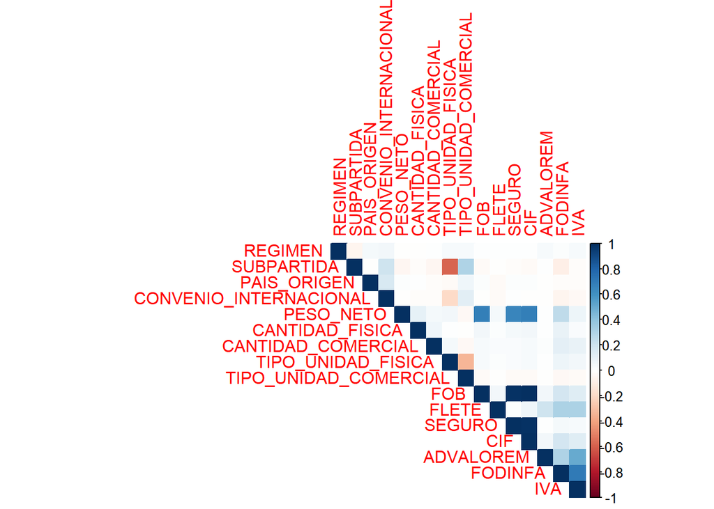

```r
library(corrplot)
# Se generó el gráfico de correlación
corrplot(matriz_correlacion, method = "color", type = "upper")
```

**Nota:** Tuve que instalar la librería “corrplot”

Con el objetivo de analizar los resultados de forma individual, se generan gráficos de barras de las correlaciones para cada una de las variables de salida, con el fin de identificar cuáles de las variables de entrada presentan un mayor impacto en cada tributo.

Este procedimiento se realiza debido a que se dispone de un número considerable de variables de entrada y no se desea utilizarlas en su totalidad, sino únicamente seleccionar las **cuatro más relevantes** para la construcción de los modelos predictivos.

**Para el IVA:**

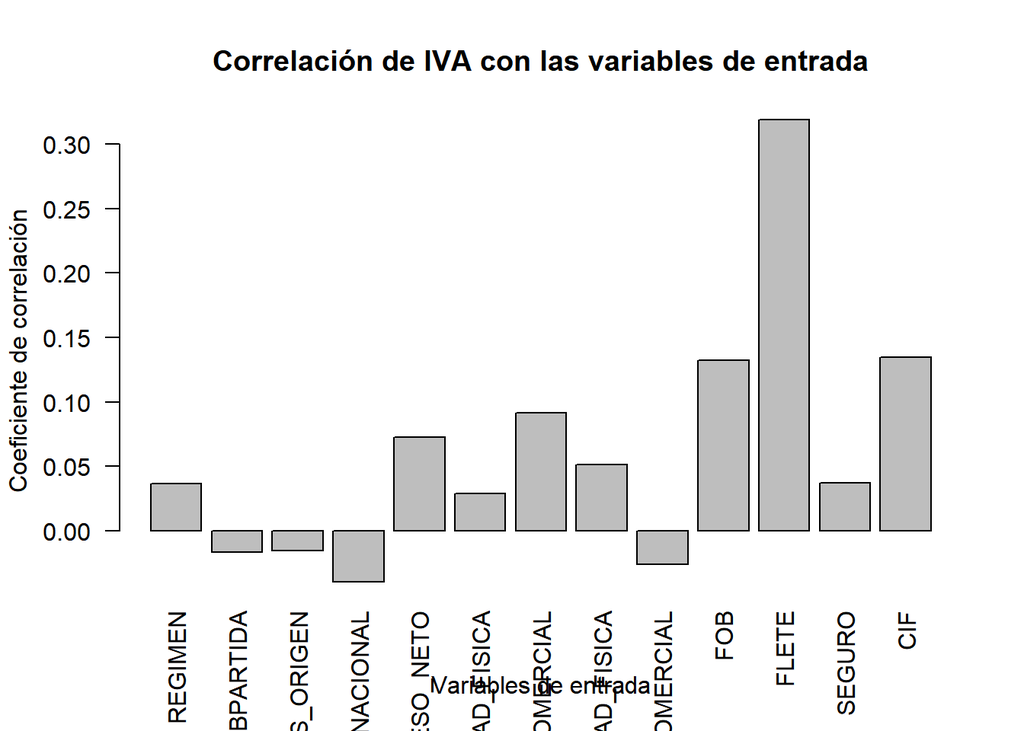

```r
# Se extrajo la correlación de IVA con todas las variables de entrada
cor_iva <- matriz_correlacion[vars_entrada, "IVA"]

# Se generó el gráfico de barras de las correlaciones
barplot(cor_iva,
        las = 2,                 # rota etiquetas del eje X
        main = "Correlación de IVA con las variables de entrada",
        ylab = "Coeficiente de correlación",
        xlab = "Variables de entrada")
```

**Para el FODINFA:**

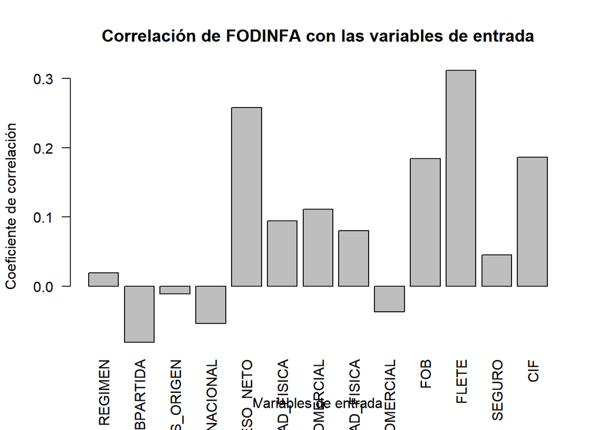

```r
cor_FODINFA <- matriz_correlacion[vars_entrada, "FODINFA"]

# Se generó el gráfico de barras de las correlaciones
barplot(cor_FODINFA,
        las = 2,                 # rota etiquetas del eje X
        main = "Correlación de FODINFA con las variables de entrada",
        ylab = "Coeficiente de correlación",
        xlab = "Variables de entrada")
```

**Para el ADVALOREM:**

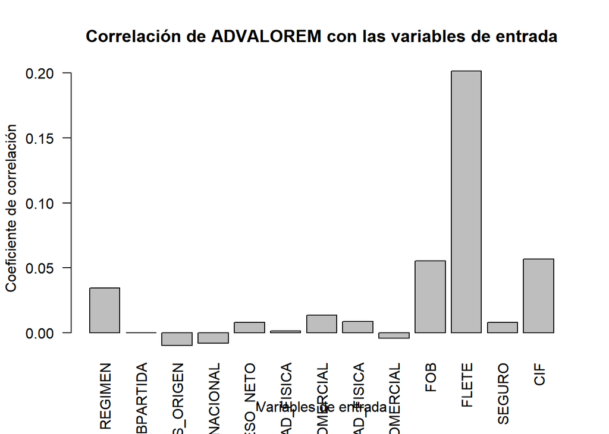

```r
cor_ADVALOREM <- matriz_correlacion[vars_entrada, "ADVALOREM"]

# Se generó el gráfico de barras de las correlaciones
barplot(cor_ADVALOREM,
        las = 2,                 # rota etiquetas del eje X
        main = "Correlación de ADVALOREM con las variables de entrada",
        ylab = "Coeficiente de correlación",
        xlab = "Variables de entrada")
```

## Resumen de los Resultados Obtenidos

Para la salida **FODINFA**, las variables de entrada de mayor influencia son:

- `FLETE`
- `PESO_NETO`
- `CIF`
- `FOB`

Finalmente, para las salidas **ADVALOREM**, las variables de entrada más relevantes son:

- `FLETE`
- `FOB`
- `CIF`
- `REGIMEN`

## Resultados del Análisis de Relacional

Como resultado del estudio, se analizó el impacto de las variables de entrada sobre las salidas del modelo, identificando aquellas con mayor relevancia para la predicción de los tributos. De esta forma, se pasó de considerar inicialmente **13 variables de entrada** a trabajar únicamente con **4 variables principales**.

```r
# Se crearon las bases de datos específicas para cada tributo
# usando como variables de entrada FLETE, FOB y CIF
# y como variable de salida el tributo correspondiente

base_IVA <- base_normalizada[, c("FLETE", "FOB", "CIF","TIPO_UNIDAD_COMERCIAL", "IVA")]
base_ADVALOREM <- base_normalizada[, c("FLETE", "FOB", "CIF","REGIMEN", "ADVALOREM")]
base_FODINFA <- base_normalizada[, c("FLETE", "FOB", "CIF","PESO_NETO", "FODINFA")]

# Verificación rápida de las cuatro bases creadas
list(
  IVA = dim(base_IVA),
  ADVALOREM = dim(base_ADVALOREM),
  FODINFA = dim(base_FODINFA)
)
```

```
## $IVA
## [1] 133493      5
##
## $ADVALOREM
## [1] 133493      5
##
## $FODINFA
## [1] 133493      5
```

# Algoritmo de Regresión **Random Forest**

Primero cargamos la ibreria y nos aseguramos de que cada vez que se corra este programa se obtengan los mismos resultados:

```r
# Se cargó la librería necesaria para Random Forest
library(randomForest)
# Se fijó la semilla para garantizar reproducibilidad
set.seed(123)
```

## Selección de la Muestra

La idea inicial era utilizar el 75% de los datos para entrenar el modelo y el 25% restante para validarlo. Sin embargo, la base de datos original contiene **133 493** filas y, al aplicar el modelo de Random Forest sobre todo el conjunto, se presentaba un cuello de botella computacional que podía superar los 20 minutos de ejecución.

Por este motivo, se decidió trabajar con una **muestra aleatoria del 10%** de la base original, equivalente a **13 400 filas**, que se considera representativa para los fines de este trabajo. Sobre esta muestra se utiliza el **70% de los datos para el entrenamiento** de los modelos y el **30% restante para la validación**.

```r
n_total <- nrow(base_normalizada)
tam_muestra <- min(13400, n_total)
idx_muestra <- sample(seq_len(n_total), size = tam_muestra)
aduana_muestra <- base_normalizada[idx_muestra, ]
dim(aduana_muestra)
```

```
## [1] 13400    16
```

```r
#Bases específicas por salida, construidas a partir de la muestra
base_IVA <- aduana_muestra[, c("FLETE", "FOB", "CIF","TIPO_UNIDAD_COMERCIAL", "IVA")]
base_ADVALOREM <- aduana_muestra[, c("FLETE", "FOB", "CIF","REGIMEN", "ADVALOREM")]
base_FODINFA <- aduana_muestra[, c("FLETE", "FOB", "CIF","PESO_NETO", "FODINFA")]

#División en entrenamiento (70%) y prueba (30%)

n_m <- nrow(aduana_muestra)
idx_entrenamiento <- sample(seq_len(n_m), size = floor(0.7 * n_m))

train_IVA <- base_IVA[idx_entrenamiento, ]
test_IVA <- base_IVA[-idx_entrenamiento, ]

train_ADVALOREM <- base_ADVALOREM[idx_entrenamiento, ]
test_ADVALOREM <- base_ADVALOREM[-idx_entrenamiento, ]

train_FODINFA <- base_FODINFA[idx_entrenamiento, ]
test_FODINFA <- base_FODINFA[-idx_entrenamiento, ]
```

## Modelos de Random Forest de regresión

A continuación, se procede al ajuste de los modelos de Random Forest de regresión para cada una de las variables de salida consideradas en el estudio, utilizando las variables de entrada previamente seleccionadas.

```r
#Modelos Random Forest para cada salida

modelo_IVA <- randomForest(
IVA ~ FLETE + FOB + CIF + TIPO_UNIDAD_COMERCIAL,
data = train_IVA,
ntree = 150,
mtry = 2,
importance = TRUE
)

modelo_ADVALOREM <- randomForest(
ADVALOREM ~ FLETE + FOB + CIF +REGIMEN,
data = train_ADVALOREM,
ntree = 150,
mtry = 2,
importance = TRUE
)

modelo_FODINFA <- randomForest(
FODINFA ~ FLETE + FOB + CIF + PESO_NETO,
data = train_FODINFA,
ntree = 150,
mtry = 2,
importance = TRUE
)
```

## Resultados del Modelo Random Forest

Con los modelos ajustados, se generan las predicciones sobre el conjunto de prueba y se calculan los indicadores de desempeño RMSE y $R^2$ para cada salida:

```r
# Predicciones sobre el conjunto de prueba

pred_IVA           <- predict(modelo_IVA, test_IVA)
pred_ADVALOREM     <- predict(modelo_ADVALOREM, test_ADVALOREM)
pred_FODINFA       <- predict(modelo_FODINFA, test_FODINFA)

# Funciones para RMSE y R²

rmse <- function(real, pred) {
sqrt(mean((real - pred)^2))
}

r2 <- function(real, pred) {
1 - sum((real - pred)^2) / sum((real - mean(real))^2)
}

# Cálculo de métricas para cada modelo

resultados_modelos <- data.frame(
Salida = c("IVA", "ADVALOREM", "FODINFA"),
RMSE = c(
rmse(test_IVA$IVA, pred_IVA),
rmse(test_ADVALOREM$ADVALOREM, pred_ADVALOREM),
rmse(test_FODINFA$FODINFA, pred_FODINFA)
),
R2 = c(
r2(test_IVA$IVA, pred_IVA),
r2(test_ADVALOREM$ADVALOREM, pred_ADVALOREM),
r2(test_FODINFA$FODINFA, pred_FODINFA)
)
)

resultados_modelos
```

```
##      Salida        RMSE         R2
## 1       IVA 0.005913098  0.5189527
## 2 ADVALOREM 0.008906366 -0.4929442
## 3   FODINFA 0.001322146  0.9865694
```

Se obtuvieron resultados de predicción muy satisfactorios para `FODINFA`, un desempeño moderado para `IVA` y un desempeño bajo para `ADVALOREM`. Con el fin de analizar estos resultados de manera visual y comparativa, a continuación se presentan los gráficos de predicción versus valor real para cada una de las salidas consideradas.

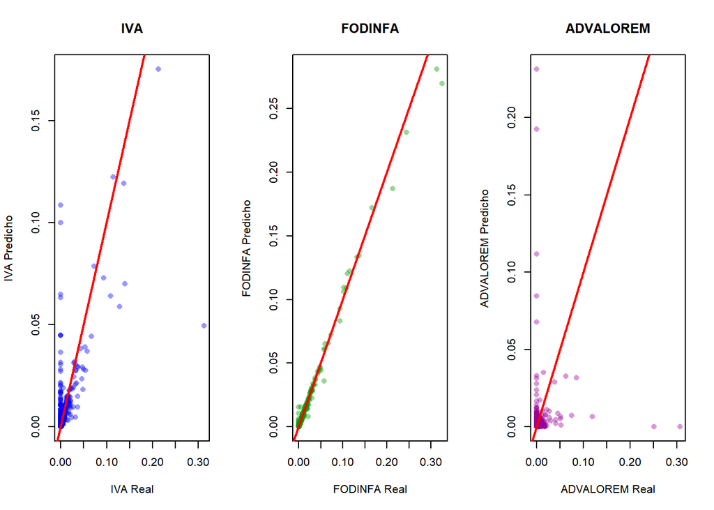

```r
# Configuración para 3 gráficos en una sola fila
par(mfrow = c(1, 3))

# === IVA ===
plot(test_IVA$IVA, pred_IVA,
     main = "IVA",
     xlab = "IVA Real",
     ylab = "IVA Predicho",
     pch = 16,
     col = rgb(0, 0, 1, 0.4))
abline(a = 0, b = 1, col = "red", lwd = 2)

# === FODINFA ===
plot(test_FODINFA$FODINFA, pred_FODINFA,
     main = "FODINFA",
     xlab = "FODINFA Real",
     ylab = "FODINFA Predicho",
     pch = 16,
     col = rgb(0, 0.6, 0, 0.4))
abline(a = 0, b = 1, col = "red", lwd = 2)

# === ADVALOREM ===
plot(test_ADVALOREM$ADVALOREM, pred_ADVALOREM,
     main = "ADVALOREM",
     xlab = "ADVALOREM Real",
     ylab = "ADVALOREM Predicho",
     pch = 16,
     col = rgb(0.6, 0, 0.6, 0.4))
abline(a = 0, b = 1, col = "red", lwd = 2)
```

```r
# Restaurar configuración gráfica por defecto
par(mfrow = c(1, 1))
```

A partir del análisis gráfico anterior, se identifica la posible presencia de valores atípicos en los datos.

## Eliminación de Atípicos

Con el fin de evaluar de manera más rigurosa la distribución de las variables de salida y confirmar la existencia de dichos valores extremos, se procede a generar diagramas de cajas y bigotes (boxplots), los cuales permiten visualizar la dispersión, la mediana y los posibles outliers de cada tributo.

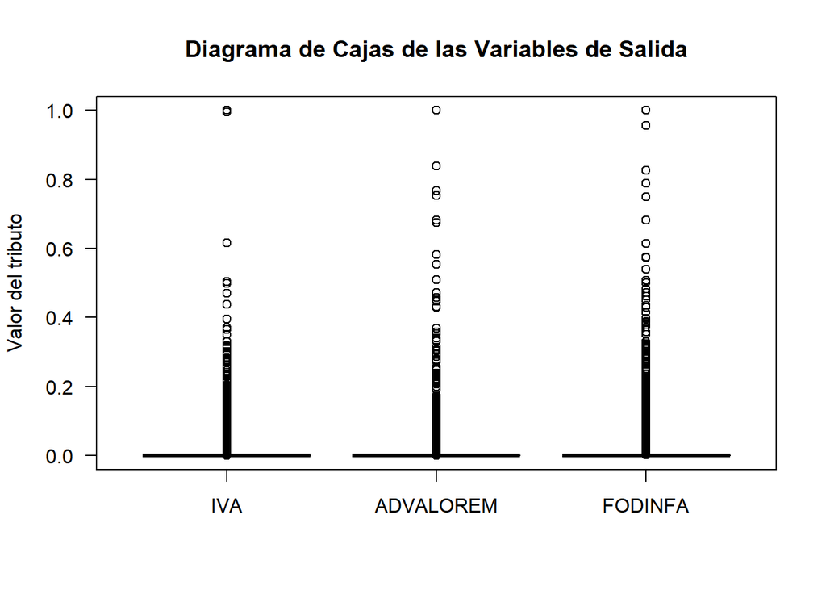

```r
boxplot(
  base_normalizada[, c("IVA", "ADVALOREM", "FODINFA")],
  main = "Diagrama de Cajas de las Variables de Salida",
  ylab = "Valor del tributo",
  col = c("lightblue", "lightgreen", "lightpink", "lightgray"),
  border = "black",
  las = 1   # etiquetas horizontales
)
```

El diagrama de cajas de las variables de salida evidencia una distribución altamente asimétrica y una presencia significativa de valores atípicos. Este comportamiento puede haber impactado negativamente en el desempeño de los modelos predictivos. En consecuencia, se procede a aplicar un proceso de eliminación de datos atípicos, con el fin de mejorar la calidad de la información y la estabilidad de los modelos.

```r
# Función para eliminar atípicos usando IQR
eliminar_outliers_IQR <- function(x) {
  Q1 <- quantile(x, 0.25, na.rm = TRUE)
  Q3 <- quantile(x, 0.75, na.rm = TRUE)
  IQR_val <- Q3 - Q1
  limite_inf <- Q1 - 1.5 * IQR_val
  limite_sup <- Q3 + 1.5 * IQR_val
  x >= limite_inf & x <= limite_sup
}

filtro_IVA  <- eliminar_outliers_IQR(base_numerica$IVA)
filtro_ADV  <- eliminar_outliers_IQR(base_numerica$ADVALOREM)
filtro_FOD  <- eliminar_outliers_IQR(base_numerica$FODINFA)

filtro_total <- filtro_IVA & filtro_ADV & filtro_FOD
base_seleccionada_sin_outliers <- base_normalizada[filtro_total, ]

dim(base_normalizada)
```

```
## [1] 133493     16
```

```r
dim(base_seleccionada_sin_outliers)
```

```
## [1] 91649    16
```

Con el fin de evaluar el impacto del proceso de eliminación de valores atípicos sobre la base de datos, se procede a generar nuevamente el diagrama de cajas, con el objetivo de comparar la distribución de las variables de salida antes y después del tratamiento aplicado.

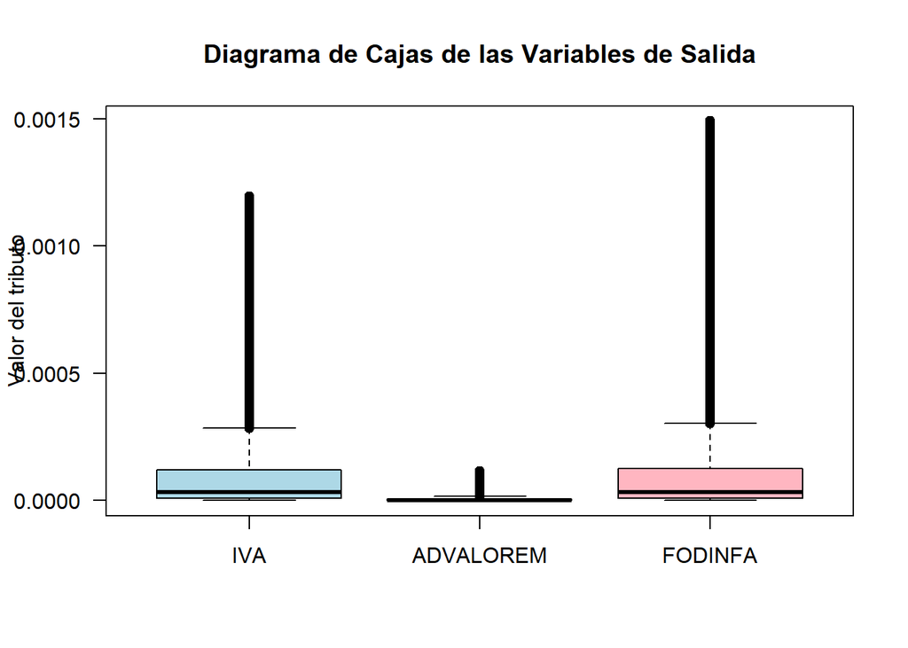

```r
boxplot(
  base_seleccionada_sin_outliers[, c("IVA", "ADVALOREM", "FODINFA")],
  main = "Diagrama de Cajas de las Variables de Salida",
  ylab = "Valor del tributo",
  col = c("lightblue", "lightgreen", "lightpink", "lightgray"),
  border = "black",
  las = 1   # etiquetas horizontales
)
```

El nuevo diagrama de cajas obtenido muestra que una parte significativa de los valores atípicos ha sido eliminada de la base de datos. No obstante, aún se conservan algunos valores que se encuentran fuera de los límites de la caja, los cuales corresponden a comportamientos propios y característicos del conjunto de datos, asociados a operaciones de importación de magnitud excepcional.

## Algoritmo Randon Forest sobre la Base Depurada

A continuación, se repite el procedimiento de modelado utilizando la base de datos sin valores atípicos, con el objetivo de evaluar si este tratamiento permite mejorar el desempeño y la capacidad predictiva de los modelos.

```r
n_total <- nrow(base_seleccionada_sin_outliers)
tam_muestra <- min(13400, n_total)
idx_muestra <- sample(seq_len(n_total), size = tam_muestra)
aduana_muestra <- base_seleccionada_sin_outliers[idx_muestra, ]
#Bases específicas por salida, construidas a partir de la muestra
base_IVA <- aduana_muestra[, c("FLETE", "FOB", "CIF","TIPO_UNIDAD_COMERCIAL", "IVA")]
base_ADVALOREM <- aduana_muestra[, c("FLETE", "FOB", "CIF","REGIMEN", "ADVALOREM")]
base_FODINFA <- aduana_muestra[, c("FLETE", "FOB", "CIF","PESO_NETO", "FODINFA")]

#División en entrenamiento (70%) y prueba (30%)

n_m <- nrow(aduana_muestra)
idx_entrenamiento <- sample(seq_len(n_m), size = floor(0.7 * n_m))

train_IVA <- base_IVA[idx_entrenamiento, ]
test_IVA <- base_IVA[-idx_entrenamiento, ]

train_ADVALOREM <- base_ADVALOREM[idx_entrenamiento, ]
test_ADVALOREM <- base_ADVALOREM[-idx_entrenamiento, ]

train_FODINFA <- base_FODINFA[idx_entrenamiento, ]
test_FODINFA <- base_FODINFA[-idx_entrenamiento, ]
modelo_IVA <- randomForest(
IVA ~ FLETE + FOB + CIF + TIPO_UNIDAD_COMERCIAL,
data = train_IVA,
ntree = 150,
mtry = 2,
importance = TRUE
)

modelo_ADVALOREM <- randomForest(
ADVALOREM ~ FLETE + FOB + CIF +REGIMEN,
data = train_ADVALOREM,
ntree = 150,
mtry = 2,
importance = TRUE
)

modelo_FODINFA <- randomForest(
FODINFA ~ FLETE + FOB + CIF + PESO_NETO,
data = train_FODINFA,
ntree = 150,
mtry = 2,
importance = TRUE
)

# Predicciones sobre el conjunto de prueba

pred_IVA           <- predict(modelo_IVA, test_IVA)
pred_ADVALOREM     <- predict(modelo_ADVALOREM, test_ADVALOREM)
pred_FODINFA       <- predict(modelo_FODINFA, test_FODINFA)

# Funciones para RMSE y R²

rmse <- function(real, pred) {
sqrt(mean((real - pred)^2))
}

r2 <- function(real, pred) {
1 - sum((real - pred)^2) / sum((real - mean(real))^2)
}

# Cálculo de métricas para cada modelo

resultados_modelos <- data.frame(
Salida = c("IVA", "ADVALOREM", "FODINFA"),
RMSE = c(
rmse(test_IVA$IVA, pred_IVA),
rmse(test_ADVALOREM$ADVALOREM, pred_ADVALOREM),
rmse(test_FODINFA$FODINFA, pred_FODINFA)
),
R2 = c(
r2(test_IVA$IVA, pred_IVA),
r2(test_ADVALOREM$ADVALOREM, pred_ADVALOREM),
r2(test_FODINFA$FODINFA, pred_FODINFA)
)
)

resultados_modelos
```

```
##      Salida         RMSE         R2
## 1       IVA 8.978903e-05 0.84311877
## 2 ADVALOREM 2.328428e-05 0.06104217
## 3   FODINFA 4.936383e-05 0.95843236
```

- **IVA:**  
  Se obtuvo un $R^2 = 0.84$, lo que indica que el modelo explica una proporción elevada de la variabilidad del tributo. El RMSE del orden de $10^{-5}$ refleja una adecuada capacidad de predicción bajo el esquema de variables utilizadas.
- **ADVALOREM:**  
  El valor de $R^2 = 0.06$ muestra un bajo poder explicativo del modelo, lo que sugiere que este tributo presenta una dependencia relevante de otras variables no incluidas en el análisis o una dinámica no lineal más compleja.
- **FODINFA:**  
  Se alcanzó un $R^2 = 0.96$, indicando que el modelo explica casi en su totalidad la variabilidad de esta salida, con un error de predicción muy bajo.

Con el fin de evidenciar de manera gráfica los efectos del tratamiento de valores atípicos, se procede a generar nuevamente los gráficos de predicción versus valor real, permitiendo una comparación directa con los resultados obtenidos antes de la depuración de los datos.

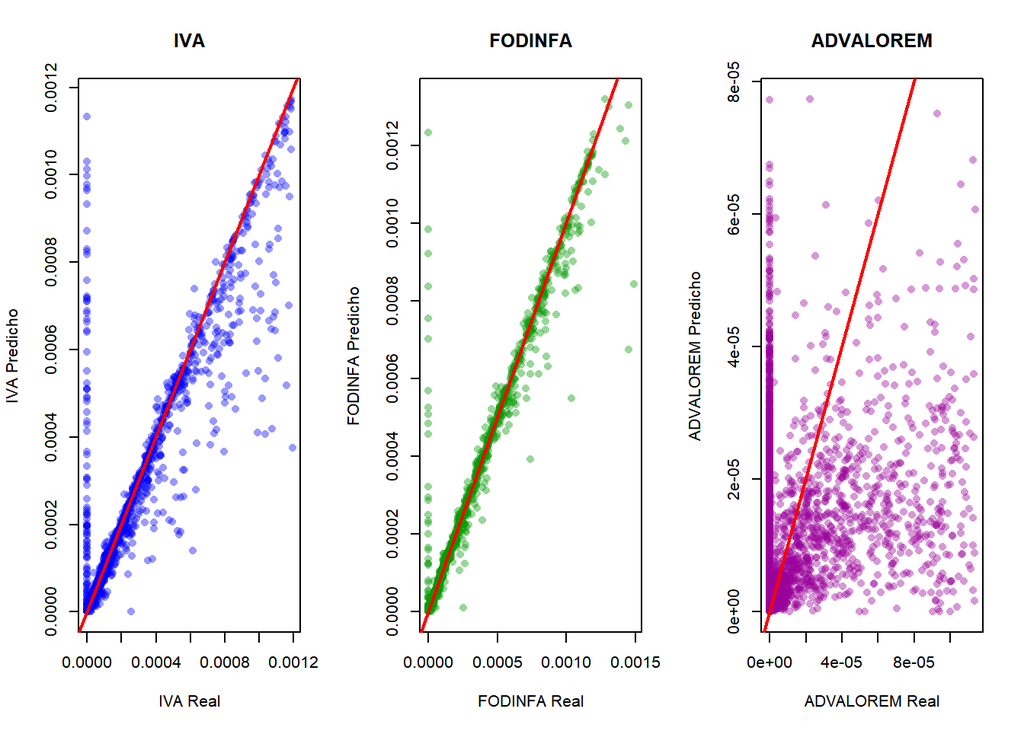

```r
# Configuración para 3 gráficos en una sola fila
par(mfrow = c(1, 3))

# === IVA ===
plot(test_IVA$IVA, pred_IVA,
     main = "IVA",
     xlab = "IVA Real",
     ylab = "IVA Predicho",
     pch = 16,
     col = rgb(0, 0, 1, 0.4))
abline(a = 0, b = 1, col = "red", lwd = 2)

# === FODINFA ===
plot(test_FODINFA$FODINFA, pred_FODINFA,
     main = "FODINFA",
     xlab = "FODINFA Real",
     ylab = "FODINFA Predicho",
     pch = 16,
     col = rgb(0, 0.6, 0, 0.4))
abline(a = 0, b = 1, col = "red", lwd = 2)

# === ADVALOREM ===
plot(test_ADVALOREM$ADVALOREM, pred_ADVALOREM,
     main = "ADVALOREM",
     xlab = "ADVALOREM Real",
     ylab = "ADVALOREM Predicho",
     pch = 16,
     col = rgb(0.6, 0, 0.6, 0.4))
abline(a = 0, b = 1, col = "red", lwd = 2)
```

```r
# Restaurar configuración gráfica por defecto
par(mfrow = c(1, 1))
```

# Conclusiones Finales

El estudio permitió demostrar la viabilidad del uso de modelos de machine learning para la estimación de tributos aduaneros a partir de información operativa disponible al arribo de la mercancía, empleando datos reales del SENAE y un enfoque estrictamente basado en analítica de datos.

El modelo de Random Forest mostró un desempeño sobresaliente para `FODINFA` (R² = 0.96) y un desempeño adecuado para `IVA` (R² = 0.84), confirmando su capacidad para capturar relaciones no lineales complejas entre las variables de entrada y salida.

En contraste, el bajo valor del coeficiente de determinación obtenido para `ADVALOREM` (R² = 0.06) evidencia que este tributo depende de factores adicionales no considerados en el modelo actual, como variables arancelarias específicas, normativa tributaria o condiciones regulatorias particulares.

Finalmente, se concluye que la metodología propuesta es adecuada para la predicción de tributos como `IVA` y `FODINFA`, mientras que para `ADVALOREM` se requiere una reformulación del conjunto de variables explicativas, incorporando información normativa y arancelaria más detallada para mejorar su capacidad predictiva.